# Air Quality API

## CURRENT CONDITIONS

The general section of the application. Here, a user wants the current air quality status of the location.

[View API docs](https://documenter.getpostman.com/view/28649677/2s9YeD9tEt)

## Basic Request

**Simple request. Moderate amount of information provided.**

```python
import requests
import matplotlib.pyplot as plt
```

```python
def get_air_quality(api_key, latitude, longitude):
    url = 'https://airquality.googleapis.com/v1/currentConditions:lookup?key=' + api_key
    headers = {'Content-Type': 'application/json'}

    payload = {
        'location': {
            'latitude': latitude,
            'longitude': longitude
        }
    }

    try:
        response = requests.post(url, json=payload, headers=headers)
        data = response.json()

        # Process the response data as needed
        return data

    except requests.exceptions.RequestException as e:
        print(f"Error: {e}")
```

```python
api_key = "AIzaSyBL41gOZg3YwFjwJByqitRpI120tQaJr-8"
latitude = 37.419734
longitude = -122.0827784
```

```python
air_quality_data = get_air_quality(api_key, latitude, longitude)
```

```python
air_quality_data
```

```
{'dateTime': '2023-11-22T17:00:00Z',
 'regionCode': 'us',
 'indexes': [{'code': 'uaqi',
   'displayName': 'Universal AQI',
   'aqi': 68,
   'aqiDisplay': '68',
   'color': {'red': 0.5647059, 'green': 0.827451, 'blue': 0.1764706},
   'category': 'Good air quality',
   'dominantPollutant': 'pm10'}]}
```

```python
datetime = air_quality_data['dateTime']
region_code = air_quality_data['regionCode']
aqi = air_quality_data['indexes'][0]['aqi']
aqi_str = air_quality_data['indexes'][0]['aqiDisplay']
color_red = air_quality_data['indexes'][0]['color']['red']
color_green = air_quality_data['indexes'][0]['color']['green']
color_blue = air_quality_data['indexes'][0]['color']['blue']
category = air_quality_data['indexes'][0]['category']
dominant_pollutant = air_quality_data['indexes'][0]['dominantPollutant']
```

```python
datetime
```

```
'2023-11-22T17:00:00Z'
```

```python
region_code
```

```
'us'
```

```python
aqi
```

```
68
```

```python
aqi_str
```

```
'68'
```

```python
color_red, color_green, color_blue
```

```
(0.5647059, 0.827451, 0.1764706)
```

```python
category
```

```
'Good air quality'
```

```python
dominant_pollutant
```

```
'pm10'
```

## Multi parameters Request

**A more complex request. Maximum amount of information provided.**

```python
def get_air_quality(api_key, latitude, longitude):
    url = 'https://airquality.googleapis.com/v1/currentConditions:lookup?key=' + api_key
    headers = {'Content-Type': 'application/json'}

    payload = {
        "universalAqi": True,
        "location": {
            "latitude": latitude,
            "longitude": longitude
        },
        "extraComputations": [
            "HEALTH_RECOMMENDATIONS",
            "DOMINANT_POLLUTANT_CONCENTRATION",
            "POLLUTANT_CONCENTRATION",
            "LOCAL_AQI",
            "POLLUTANT_ADDITIONAL_INFO"
        ],
        "languageCode": "en"
    }

    try:
        response = requests.post(url, json=payload, headers=headers)
        data = response.json()

        # Process the response data as needed
        return data

    except requests.exceptions.RequestException as e:
        print(f"Error: {e}")
```

```python
api_key = "AIzaSyBL41gOZg3YwFjwJByqitRpI120tQaJr-8"
latitude = 37.419734
longitude = -122.0827784
```

```python
air_quality_data = get_air_quality(api_key, latitude, longitude)
```

```python
air_quality_data
```

```
{'dateTime': '2023-11-22T18:00:00Z',
 'regionCode': 'us',
 'indexes': [{'code': 'uaqi',
   'displayName': 'Universal AQI',
   'aqi': 59,
   'aqiDisplay': '59',
   'color': {'red': 0.78039217, 'green': 0.9137255, 'blue': 0.08627451},
   'category': 'Moderate air quality',
   'dominantPollutant': 'pm10'},
  {'code': 'usa_epa',
   'displayName': 'AQI (US)',
   'aqi': 43,
   'aqiDisplay': '43',
   'color': {'green': 0.89411765},
   'category': 'Good air quality',
   'dominantPollutant': 'pm25'}],
 'pollutants': [{'code': 'co',
   'displayName': 'CO',
   'fullName': 'Carbon monoxide',
   'concentration': {'value': 741.44, 'units': 'PARTS_PER_BILLION'},
   'additionalInfo': {'sources': 'Typically originates from incomplete combustion of carbon fuels, such as that which occurs in car engines and power plants.',
    'effects': 'When inhaled, carbon monoxide can prevent the blood from carrying oxygen. Exposure may cause dizziness, nausea and headaches. Exposure to extreme concentrations can lead to loss of consciousness.'}},
  {'code': 'no2',
   'displayName': 'NO2',
   'fullName': 'Nitrogen dioxide',
   'concentration': {'value': 32.11, 'units': 'PARTS_PER_BILLION'},
   'additionalInfo': {'sources': 'Main sources are fuel burning processes, such as those used in industry and transportation.',
    'effects': 'Exposure may cause increased bronchial reactivity in patients with asthma, lung function decline in patients with Chronic Obstructive Pulmonary Disease (COPD), and increased risk of respiratory infections, especially in young children.'}},
  {'code': 'o3',
   'displayName': 'O3',
   'fullName': 'Ozone',
   'concentration': {'value': 12.14, 'units': 'PARTS_PER_BILLION'},
   'additionalInfo': {'sources': 'Ozone is created in a chemical reaction between atmospheric oxygen, nitrogen oxides, carbon monoxide and organic compounds, in the presence of sunlight.',
    'effects': 'Ozone can irritate the airways and cause coughing, a burning sensation, wheezing and shortness of breath. Additionally, ozone is one of the major components of photochemical smog.'}},
  {'code': 'pm10',
   'displayName': 'PM10',
   'fullName': 'Inhalable particulate matter (<10µm)',
   'concentration': {'value': 45.67, 'units': 'MICROGRAMS_PER_CUBIC_METER'},
   'additionalInfo': {'sources': 'Main sources are combustion processes (e.g. indoor heating, wildfires), mechanical processes (e.g. construction, mineral dust, agriculture) and biological particles (e.g. pollen, bacteria, mold).',
    'effects': 'Inhalable particles can penetrate into the lungs. Short term exposure can cause irritation of the airways, coughing, and aggravation of heart and lung diseases, expressed as difficulty breathing, heart attacks and even premature death.'}},
  {'code': 'pm25',
   'displayName': 'PM2.5',
   'fullName': 'Fine particulate matter (<2.5µm)',
   'concentration': {'value': 10.09, 'units': 'MICROGRAMS_PER_CUBIC_METER'},
   'additionalInfo': {'sources': 'Main sources are combustion processes (e.g. power plants, indoor heating, car exhausts, wildfires), mechanical processes (e.g. construction, mineral dust) and biological particles (e.g. bacteria, viruses).',
    'effects': 'Fine particles can penetrate into the lungs and bloodstream. Short term exposure can cause irritation of the airways, coughing and aggravation of heart and lung diseases, expressed as difficulty breathing, heart attacks and even premature death.'}},
  {'code': 'so2',
   'displayName': 'SO2',
   'fullName': 'Sulfur dioxide',
   'concentration': {'value': 1.18, 'units': 'PARTS_PER_BILLION'},
   'additionalInfo': {'sources': 'Main sources are burning processes of sulfur-containing fuel in industry, transportation and power plants.',
    'effects': 'Exposure causes irritation of the respiratory tract, coughing and generates local inflammatory reactions. These in turn, may cause aggravation of lung diseases, even with short term exposure.'}}],
 'healthRecommendations': {'generalPopulation': 'If you start to feel respiratory discomfort such as coughing or breathing difficulties, consider reducing the intensity of your outdoor activities. Try to limit the time you spend near busy roads, construction sites, open fires and other sources of sm…
  'elderly': 'Reduce the intensity of your outdoor activities. It is recommended to limit the time you are near busy roads, construction sites, open fires and other sources of smoke. Staying indoors with an activated air filtration system would be best for your long term health.',
  'lungDiseasePopulation': 'Reduce the intensity of your outdoor activities. Keep relevant medication(s) available and consult a doctor with any questions. It is recommended to limit the time you are near busy roads, open fires and other sources of smoke. In addition, consider reducing the time you …
  'heartDiseasePopulation': 'Reduce the intensity of your outdoor activities. Keep relevant medication(s) available and consult a doctor with any questions. It is recommended to limit the time you are near busy roads, construction sites, open fires and other sources of smoke. In addition, consider r…
  'athletes': 'Reduce the intensity of your outdoor activities. It is recommended to limit the time you are near busy roads, construction sites, open fires and other sources of smoke. In addition, consider reducing the time you spend near industrial emission stacks. Staying indoors with an activated…
  'pregnantWomen': 'To keep you and your baby healthy, reduce the intensity of your outdoor activities. It is recommended to limit the time you are near busy roads, construction sites, open fires and other sources of smoke. Staying indoors with an activated air filtration system would be best for yo…
  'children': 'Reduce the intensity of your outdoor activities. It is recommended to limit the time you are near busy roads, construction sites, open fires and other sources of smoke. Staying indoors with an activated air filtration system would be best for your long term health.'}}
```

```python
# Extracting all the data from the json response
datetime = air_quality_data['dateTime']
region_code = air_quality_data['regionCode']
aqi = air_quality_data['indexes'][0]['aqi']
aqi_str = air_quality_data['indexes'][0]['aqiDisplay']
color_red = air_quality_data['indexes'][0]['color']['red']
color_green = air_quality_data['indexes'][0]['color']['green']
color_blue = air_quality_data['indexes'][0]['color']['blue']
category = air_quality_data['indexes'][0]['category']
dominant_pollutant = air_quality_data['indexes'][0]['dominantPollutant']
```

**This is where the "extra information" is. We add extra information on the source of the main pollutant and health recommendations for different category of people.**

```python
pollutants = air_quality_data['pollutants']

for pollutant in pollutants:
    if pollutant['code'] == dominant_pollutant:  # checking to obtain only information on the dominant pollutant
        dominant_pollutant_data = pollutant  # store it in a new variable

print(dominant_pollutant_data)
```

```
{'code': 'pm10', 'displayName': 'PM10', 'fullName': 'Inhalable particulate matter (<10µm)', 'concentration': {'value': 45.67, 'units': 'MICROGRAMS_PER_CUBIC_METER'}, 'additionalInfo': {'sources': 'Main sources are combustion processes (e.g. indoor heating, wildfires), mechanical processes (e.g. cons…
```

**Extra information on the dominant pollutant**

```python
# Extract extra information on the dominant pollutant
code = dominant_pollutant_data['code']
full_name = dominant_pollutant_data['fullName']
conc_value = dominant_pollutant_data['concentration']['value']
conc_value_unit = dominant_pollutant_data['concentration']['units']
pollutant_source = dominant_pollutant_data['additionalInfo']['sources']
pollutant_effect = dominant_pollutant_data['additionalInfo']['effects']
```

```python
code
```

```
'pm10'
```

```python
full_name
```

```
'Inhalable particulate matter (<10µm)'
```

```python
conc_value
```

```
45.67
```

```python
conc_value_unit
```

```
'MICROGRAMS_PER_CUBIC_METER'
```

```python
pollutant_source
```

```
'Main sources are combustion processes (e.g. indoor heating, wildfires), mechanical processes (e.g. construction, mineral dust, agriculture) and biological particles (e.g. pollen, bacteria, mold).'
```

```python
pollutant_effect
```

```
'Inhalable particles can penetrate into the lungs. Short term exposure can cause irritation of the airways, coughing, and aggravation of heart and lung diseases, expressed as difficulty breathing, heart attacks and even premature death.'
```

**So we can display this as a way to better inform the user on the dominant pollutant. We could also display for every pollutant detected if our designer can make it possible.**

### HEALTH RECOMMENDATIONS

**There are different recommendations for different category of people.**

```python
general_population = air_quality_data['healthRecommendations']['generalPopulation']
elderly = air_quality_data['healthRecommendations']['elderly']
lung_disease_pop = air_quality_data['healthRecommendations']['lungDiseasePopulation']
heart_disease_pop = air_quality_data['healthRecommendations']['heartDiseasePopulation']
athletes = air_quality_data['healthRecommendations']['athletes']
pregnant_women = air_quality_data['healthRecommendations']['pregnantWomen']
children = air_quality_data['healthRecommendations']['children']
```

```python
general_population
```

```
'If you start to feel respiratory discomfort such as coughing or breathing difficulties, consider reducing the intensity of your outdoor activities. Try to limit the time you spend near busy roads, construction sites, open fires and other sources of smoke.'
```

```python
elderly
```

```
'Reduce the intensity of your outdoor activities. It is recommended to limit the time you are near busy roads, construction sites, open fires and other sources of smoke. Staying indoors with an activated air filtration system would be best for your long term health.'
```

```python
lung_disease_pop
```

```
'Reduce the intensity of your outdoor activities. Keep relevant medication(s) available and consult a doctor with any questions. It is recommended to limit the time you are near busy roads, open fires and other sources of smoke. In addition, consider reducing the time you spend near industrial emiss…
```

```python
heart_disease_pop
```

```
'Reduce the intensity of your outdoor activities. Keep relevant medication(s) available and consult a doctor with any questions. It is recommended to limit the time you are near busy roads, construction sites, open fires and other sources of smoke. In addition, consider reducing the time you spend n…
```

```python
athletes
```

```
'Reduce the intensity of your outdoor activities. It is recommended to limit the time you are near busy roads, construction sites, open fires and other sources of smoke. In addition, consider reducing the time you spend near industrial emission stacks. Staying indoors with an activated air filtratio…
```

```python
pregnant_women
```

```
'To keep you and your baby healthy, reduce the intensity of your outdoor activities. It is recommended to limit the time you are near busy roads, construction sites, open fires and other sources of smoke. Staying indoors with an activated air filtration system would be best for your long term health…
```

```python
children
```

```
'Reduce the intensity of your outdoor activities. It is recommended to limit the time you are near busy roads, construction sites, open fires and other sources of smoke. Staying indoors with an activated air filtration system would be best for your long term health.'
```

## HOURLY HISTORY

Might add as another feature. Maybe the user wants to get details on the past history of air quality.

We can also use visualizations here to display the air quality history.

The history period cannt exceed the last **30 days**

### Example of a single hour request

```python
def get_air_quality_history(api_key, latitude, longitude, date_time):
    url = 'https://airquality.googleapis.com/v1/history:lookup?key=' + api_key
    headers = {'Content-Type': 'application/json'}

    payload = {
        "dateTime": date_time,
        "location": {
            "latitude": latitude,
            "longitude": longitude
        }
    }

    try:
        response = requests.post(url, json=payload, headers=headers)
        data = response.json()

        # Process the response data as needed
        return data

    except requests.exceptions.RequestException as e:
        print(f"Error: {e}")
```

```python
api_key = "AIzaSyBL41gOZg3YwFjwJByqitRpI120tQaJr-8"
latitude = 37.419734
longitude = -122.0827784
date_time = "2023-11-16T15:01:23Z"
```

```python
air_quality_history = get_air_quality_history(api_key, latitude, longitude, date_time)
```

```python
air_quality_history
```

```
{'hoursInfo': [{'dateTime': '2023-11-16T15:00:00Z',
   'indexes': [{'code': 'uaqi',
     'displayName': 'Universal AQI',
     'aqi': 77,
     'aqiDisplay': '77',
     'color': {'red': 0.39607844, 'green': 0.7647059, 'blue': 0.20392157},
     'category': 'Good air quality',
     'dominantPollutant': 'pm10'}]}],
 'regionCode': 'us'}
```

### Time range request

```python
def get_air_quality_history(api_key, latitude, longitude, start_time, end_time, page_size=12, page_token=""):
    url = 'https://airquality.googleapis.com/v1/history:lookup?key=' + api_key
    headers = {'Content-Type': 'application/json'}

    payload = {
        "period": {
            "startTime": start_time,
            "endTime": end_time
        },
        "pageSize": page_size,
        "pageToken": page_token,
        "location": {
            "latitude": latitude,
            "longitude": longitude
        }
    }

    try:
        response = requests.post(url, json=payload, headers=headers)
        data = response.json()

        # Process the response data as needed
        return data

    except requests.exceptions.RequestException as e:
        print(f"Error: {e}")
```

```python
api_key = "AIzaSyBL41gOZg3YwFjwJByqitRpI120tQaJr-8"
latitude = 37.419734
longitude = -122.0827784
start_time = "2023-11-16T09:00:00Z"
end_time = "2023-11-16T20:00:00Z"
```

```python
air_quality_history = get_air_quality_history(api_key, latitude, longitude, start_time, end_time)
```

```python
air_quality_history
```

```
{'hoursInfo': [{'dateTime': '2023-11-16T20:00:00Z',
   'indexes': [{'code': 'uaqi',
     'displayName': 'Universal AQI',
     'aqi': 64,
     'aqiDisplay': '64',
     'color': {'red': 0.65882355, 'green': 0.8666667, 'blue': 0.13725491},
     'category': 'Good air quality',
     'dominantPollutant': 'pm10'}]},
  {'dateTime': '2023-11-16T19:00:00Z',
   'indexes': [{'code': 'uaqi',
     'displayName': 'Universal AQI',
     'aqi': 62,
     'aqiDisplay': '62',
     'color': {'red': 0.70980394, 'green': 0.8862745, 'blue': 0.11764706},
     'category': 'Good air quality',
     'dominantPollutant': 'no2'}]},
  {'dateTime': '2023-11-16T18:00:00Z',
   'indexes': [{'code': 'uaqi',
     'displayName': 'Universal AQI',
     'aqi': 66,
     'aqiDisplay': '66',
     'color': {'red': 0.6117647, 'green': 0.84705883, 'blue': 0.15686275},
     'category': 'Good air quality',
     'dominantPollutant': 'pm10'}]},
  {'dateTime': '2023-11-16T17:00:00Z',
   'indexes': [{'code': 'uaqi',
     'displayName': 'Universal AQI',
     'aqi': 74,
     'aqiDisplay': '74',
     'color': {'red': 0.44705883, 'green': 0.78431374, 'blue': 0.2},
     'category': 'Good air quality',
     'dominantPollutant': 'pm10'}]},
  {'dateTime': '2023-11-16T16:00:00Z',
   'indexes': [{'code': 'uaqi',
     'displayName': 'Universal AQI',
     'aqi': 82,
     'aqiDisplay': '82',
     'color': {'red': 0.30980393, 'green': 0.73333335, 'blue': 0.20784314},
     'category': 'Excellent air quality',
     'dominantPollutant': 'no2'}]},
```

[output cut: 42 more lines]

```
     'displayName': 'Universal AQI',
     'aqi': 83,
     'aqiDisplay': '83',
     'color': {'red': 0.2901961, 'green': 0.7254902, 'blue': 0.21176471},
     'category': 'Excellent air quality',
     'dominantPollutant': 'pm10'}]},
  {'dateTime': '2023-11-16T09:00:00Z',
   'indexes': [{'code': 'uaqi',
     'displayName': 'Universal AQI',
     'aqi': 76,
     'aqiDisplay': '76',
     'color': {'red': 0.4117647, 'green': 0.77254903, 'blue': 0.20392157},
     'category': 'Good air quality',
     'dominantPollutant': 'pm10'}]}],
 'regionCode': 'us'}
```

From this history information, we can plot something like **Air quality of the last 12 hours**.

```python
# Extract data to plot the line plot
datetime = [time['dateTime'] for time in air_quality_history['hoursInfo']]
aqi = [index['indexes'][0]['aqi'] for index in air_quality_history['hoursInfo']]
```

```python
datetime
```

```
['2023-11-16T20:00:00Z',
 '2023-11-16T19:00:00Z',
 '2023-11-16T18:00:00Z',
 '2023-11-16T17:00:00Z',
 '2023-11-16T16:00:00Z',
 '2023-11-16T15:00:00Z',
 '2023-11-16T14:00:00Z',
 '2023-11-16T13:00:00Z',
 '2023-11-16T12:00:00Z',
 '2023-11-16T11:00:00Z',
 '2023-11-16T10:00:00Z',
 '2023-11-16T09:00:00Z']
```

```python
aqi
```

```
[64, 62, 66, 74, 82, 77, 83, 89, 89, 84, 83, 76]
```

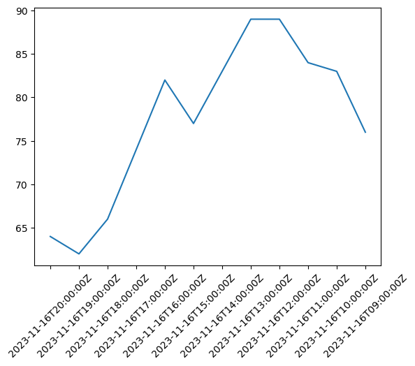

```python
plt.plot(datetime, aqi);
plt.xticks(rotation=45);
```

**Something like this on the design. This is a rough plot. We can make it look better.**